# Case study: null subjects

Gemma Hunter McCarley

September 2023

# 1 Introduction

The null subjects case study analyzed data from the (not yet published) CorDELES corpus. Samples pulled from the texts listed in “CorDELES Texts & Sources” were transcribed, parsed by the Stanford Parser (https://nlp.stanford.edu/software/spanish-faq.html), annotated by hand in xml, and then exported to csv. The datasets used in this study consist of the following columns:

- cordeles_2023.csv (each pronoun is a data point)
  - **docID**: the unique ID for each document made up of country + century + title, e.g. *dr16ent* = Dominican Republic, 16th century, *Entrémes*.
  - **sentenceID**: the sentence number automated by the Stanford Parser.
  - **sub_dep**: a marker for subjecthood, all are **nsubj** (a remnant of the universal dependencies used by the parser).
  - **subid**: the token ID of the subject.
  - **sub_word**: the lexical subject. In the case of multiple token subjects, a single token within the noun phrase was taken to represent the subject as a whole.
  - **sub_POS**: the part-of-speech of the subject. In this dataset, **sub_POS** can either be **NULL** or **OVERT**.
  - **Title**: full (or shortened, in the case of very long titles) text title.
  - **Region**: broader geographical grouping than country consisting of three levels (**Caribbean**, **South America**, **Peninsular (Spain)**).
  - **Country**: the country the text is from. For the most part this is also the country the author is from or was predominantly raised in; however, the earliest texts in the 16th century are naturally Spain-born authors who settled for a significant period in the specified country.
  - **Century**: the century the text was written in.
  - **Year**: the year the text was written in. Some texts only had a range for year, in which case the average was taken.
  - **Macro_Region**: the broadest geographical grouping consisting of two levels (**Spain** or **Non-Spain**).
  - **ORSCORE**: the degree of orality calculated for each text.
  - **Genre**: the initial binary genre split between literary (**LIT**) and non-literary (**DOC**) texts, plus a tag for supplemental texts (**SUPP**).
- orality.csv (each text is a data point)
  - **docID**, **ORSCORE**, and **Country** are the same as above.
  - **OVERT_RATE**: the proportion of overt subject pronouns per text.
  - **orality**: a categorical ranking of **ORSCOREs** split into **LOW** (0.00-0.25), **MID** (0.26-0.50), **HIGH** (0.51-0.75), and **HUGE** (1.00+). There isn’t a tag for **ORSCOREs** between 0.76 and 1.00 as no text falls in that range.

The code in the following sections was run using R version 4.3.0.

# 2 Load dependencies and data

```r
library(tidyverse)
library(lme4)
library(DHARMa)
library(car)
library(ggsci)
library(gridExtra)

mydata <- read.csv("cordeles_2023.csv", header = TRUE, encoding = "UTF-8")
orality <- read.csv("orality.csv", header = TRUE, encoding = "UTF-8")

# get rid of duplicate data (translation of another text)
orality <- subset(orality, docID != "CPMTpoSP")
```

# 3 Plots and models

## 3.1 Orality plot and regression

```r
# plot
orality$Country <- ifelse(orality$country == "DR", "Dominican Republic", orality$country)
orality$Country <- factor(orality$Country)
orality_plot_regression <- ggplot(data = orality, aes(x = ORSCORE, y = OVERT_RATE)) +
    geom_smooth(method = "lm", se = FALSE, color = "black") + labs(x = "ORSCORE",
    y = "Proportion of overt pronouns") + geom_point(size = 3, aes(pch = Country,
    color = Country)) + theme_bw() + scale_color_npg()

# save to external file
ggsave("Figure2.pdf", plot = orality_plot_regression, height = 3.5, width = 6)


# model
xmdl <- lm(OVERT_RATE ~ ORSCORE, data = orality)
summary(xmdl)
```

```
##
## Call:
## lm(formula = OVERT_RATE ~ ORSCORE, data = orality)
##
## Residuals:
##      Min       1Q   Median       3Q      Max
## -0.08527 -0.05271 -0.01067  0.03651  0.18698
##
## Coefficients:
##             Estimate Std. Error t value Pr(>|t|)
## (Intercept)  0.05016    0.01537   3.263 0.002465 **
## ORSCORE      0.10030    0.02307   4.348 0.000113 ***
## ---
## Signif. codes:  0 '***' 0.001 '**' 0.01 '*' 0.05 '.' 0.1 ' ' 1
##
## Residual standard error: 0.06403 on 35 degrees of freedom
## Multiple R-squared:  0.3507, Adjusted R-squared:  0.3322
## F-statistic: 18.91 on 1 and 35 DF,  p-value: 0.0001128
```

## 3.2 Pronoun proportions plot

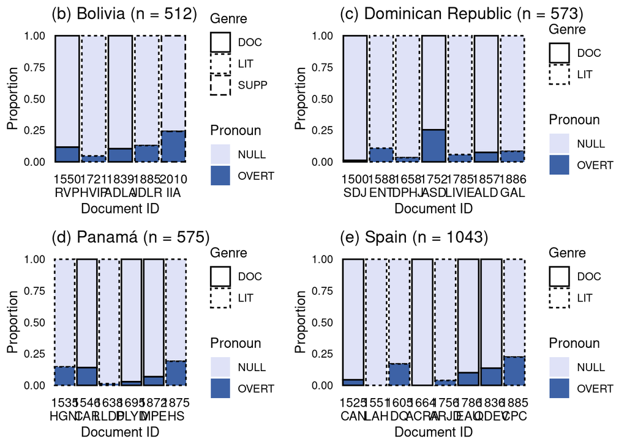

```r
# Pronoun Plots####

pronoun_plot <- function(mydata, country, panelID, type = "regular") {
    # make country specific (country, re-leveling, and year labels):
    data <- filter(mydata, Country == country)

    if (country == "Colombia") {
        data$docID <- factor(data$docID, levels = c("co16oyc", "co16evii", "co17vdm",
            "co17gnrg", "co18gsfb", "co18ppym", "co19ihdc", "CPMTpr", "CPMTpoOG",
            "CPMTpoSP", "CPMTpl", "co19syl"))
        docs <- c("1563\nOYC", "1589\nEVII", "1614\nVDM", "1674\nGNRG", "1787\nGSFB",
            "1792\nPPYM", "1844\nIHDC", "1877\nPR", "1877\nPOog", "1877\nPOsp", "1880\nPL",
            "1882\nSYL")
    } else if (country == "Dominican Republic") {
        data$docID <- factor(data$docID, levels = c("dr16sdj", "dr16ent", "dr17dphj",
            "dr18asd", "dr18livie", "dr19ald", "dr19gal"))
        docs <- c("1500\nSDJ", "1588\nENT", "1658\nDPHJ", "1752\nASD", "1785\nLIVIE",
            "1857\nALD", "1886\nGAL")
    } else if (country == "Bolivia") {
        data$docID <- factor(data$docID, levels = c("bo16rvp", "bo18hvip", "bo19adla",
            "bo19jdlr", "bo21iia"))
        docs <- c("1550\nRVP", "1721\nHVIP", "1839\nADLA", "1885\nJDLR", "2010\nIIA")
    } else if (country == "Panamá") {
        data$docID <- factor(data$docID, levels = c("pa16hgni", "pa16car", "pa17lldp",
            "pa17dlyd", "pa19mpe", "pa19hs"))
        docs <- c("1535\nHGNI", "1546\nCAR", "1638\nLLDP", "1695\nDLYD", "1872\nMPE",
            "1875\nHS")
    } else if (country == "Spain") {
        data$docID <- factor(data$docID, levels = c("sp16can", "sp16lah", "sp17dq",
            "sp17acra", "sp18arjd", "sp18eau", "sp19qdev", "sp19cpc"))
        docs <- c("1525\nCAN", "1551\nLAH", "1605\nDQ", "1664\nACRA", "1756\nARJD",
            "1786\nEAU", "1836\nQDEV", "1885\nCPC")
    }

    # plot (repeat for each country)
    barchart <- data %>%
        ggplot(aes(x = docID, fill = sub_POS)) + scale_x_discrete(labels = docs) +
        geom_bar(position = "fill", aes(color = Genre, lty = Genre), linewidth = 0.6) +
        ylab("Proportion") + xlab("Document ID") + guides(fill = guide_legend(title = "Pronoun"),
        color = guide_legend(override.aes = list(fill = NA), title = "Genre")) +
        theme_minimal() + theme(panel.grid.major = element_blank(), panel.grid.minor = element_blank())

    barchart <- barchart + ggtitle(paste0("(", panelID, ") ", country, " (n = ",
        nrow(data), ")"))

    if (type == "supp") {
        # barchart <- barchart + scale_fill_manual(values = c('NULL' =
        # '#7294D4', 'OVERT' = '#C6CDF7')) + scale_color_manual(values =
        # c('DOC' = 'black', 'LIT' = 'white', 'SUPP' = 'gold')) +
        # theme(axis.text.x = element_text(size = 9, color = 'black'))
        barchart <- barchart + scale_fill_manual(values = c(OVERT = "#3d62a6", `NULL` = "#dfe2f7")) +
            scale_color_manual(values = c(DOC = "black", LIT = "black", SUPP = "black")) +
            theme(axis.text.x = element_text(size = 10, color = "black"), axis.text.y = element_text(color = "black"))
        # supp genre ^^^
    } else if (type == "regular") {
        barchart <- barchart + scale_fill_manual(values = c(`NULL` = "#7294D4", OVERT = "#C6CDF7")) +
            scale_color_manual(values = c(DOC = "black", LIT = "white")) + theme(axis.text.x = element_text(size = 10,
            color = "black"), axis.text.y = element_text(color = "black"))
        # regular ^^^
    }

    barchart
}

mydata$Country <- ifelse(mydata$Country == "DR", "Dominican Republic", mydata$Country)
mydata$Country <- factor(mydata$Country)

pp1 <- pronoun_plot(mydata, country = "Colombia", type = "supp", panelID = "a")
pp2 <- pronoun_plot(mydata, country = "Bolivia", type = "supp", panelID = "b")
pp3 <- pronoun_plot(mydata, country = "Dominican Republic", type = "supp", panelID = "c")
pp4 <- pronoun_plot(mydata, country = "Panamá", type = "supp", panelID = "d")
pp5 <- pronoun_plot(mydata, country = "Spain", type = "supp", panelID = "e")

# combined plot
combined_plot <- grid.arrange(pp2, pp3, pp4, pp5, nrow = 2, ncol = 2, widths = c(0.85,
    1))
```

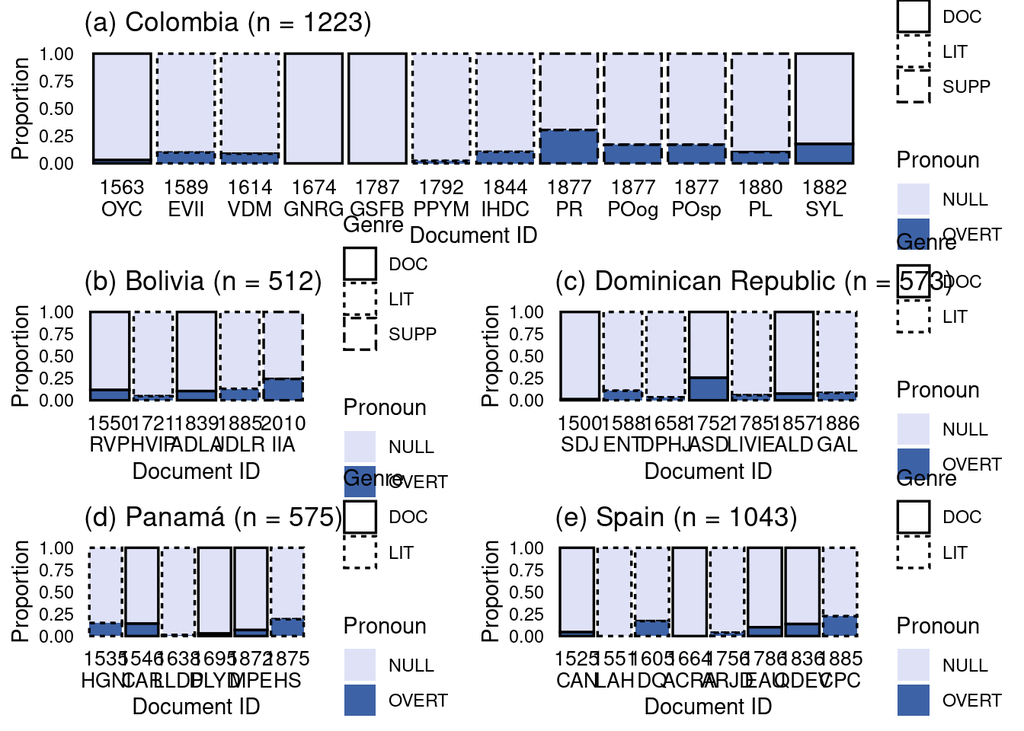

```r
combined_plot <- grid.arrange(pp1, combined_plot, nrow = 2, ncol = 1, heights = c(1.1,
    2))
```

```r
# save to external file
ggsave("Figure3.pdf", plot = combined_plot, height = 10, width = 9)
```

## 3.3 Main model

```r
# Main Model#### Get data ready
binary_null <- within(mydata, Country <- relevel(factor(Country), ref = "Spain"))  #make Spain the reference level for Country
binary_null <- within(binary_null, Macro_Region <- relevel(factor(Macro_Region),
    ref = "Spain"))  #make Spain the reference level for Macro_Region

binary_null %>%
    select(Region, Genre, sub_POS, Country, Year, ORSCORE, docID, Century, Macro_Region) %>%
    na.omit() %>%
    mutate(Century = as.factor(Century)) -> binary_null

binary_null <- subset(binary_null, binary_null$docID != "CPMTpoSP")  #get rid of duplicate data (translation of another text)

# Model
binary_null_mdl_int <- glmer(factor(sub_POS) ~ scale(Year) * scale(ORSCORE) + Macro_Region +
    (1 | docID), data = binary_null, family = "binomial")
```

# 4 Tests

```r
# tests
summary(binary_null_mdl_int)
```

```
## Generalized linear mixed model fit by maximum likelihood (Laplace
##   Approximation) [glmerMod]
##  Family: binomial  ( logit )
## Formula: factor(sub_POS) ~ scale(Year) * scale(ORSCORE) + Macro_Region +
##     (1 | docID)
##    Data: binary_null
##
##      AIC      BIC   logLik deviance df.resid
##   2548.2   2585.6  -1268.1   2536.2     3767
##
## Scaled residuals:
##     Min      1Q  Median      3Q     Max
## -0.5568 -0.4031 -0.2986 -0.2208  7.2692
##
## Random effects:
##  Groups Name        Variance Std.Dev.
##  docID  (Intercept) 0.3119   0.5585
## Number of obs: 3773, groups:  docID, 37
##
## Fixed effects:
##                            Estimate Std. Error z value Pr(>|z|)
## (Intercept)                -2.54816    0.27570  -9.242  < 2e-16 ***
## scale(Year)                 0.05029    0.15364   0.327 0.743434
## scale(ORSCORE)              1.02970    0.26917   3.825 0.000131 ***
## Macro_RegionNon-Spain       0.62880    0.31997   1.965 0.049389 *
## scale(Year):scale(ORSCORE) -0.43702    0.20634  -2.118 0.034177 *
## ---
## Signif. codes:  0 '***' 0.001 '**' 0.01 '*' 0.05 '.' 0.1 ' ' 1
##
## Correlation of Fixed Effects:
##             (Intr) scl(Y) s(ORSC M_RN-S
## scale(Year)  0.086
## sc(ORSCORE) -0.053 -0.577
## Mcr_RgnNn-S -0.831 -0.307  0.388
## s(Y):(ORSCO -0.180  0.356 -0.723 -0.170
```

```r
drop1(binary_null_mdl_int, test = "Chisq")
```

```
## Single term deletions
##
## Model:
## factor(sub_POS) ~ scale(Year) * scale(ORSCORE) + Macro_Region +
##     (1 | docID)
##                            npar    AIC    LRT Pr(Chi)
## <none>                          2548.2
## Macro_Region                  1 2550.0 3.8159 0.05077 .
## scale(Year):scale(ORSCORE)    1 2550.6 4.4147 0.03563 *
## ---
## Signif. codes:  0 '***' 0.001 '**' 0.01 '*' 0.05 '.' 0.1 ' ' 1
```

```r
Anova(binary_null_mdl_int, type = "III")
```

```
## Analysis of Deviance Table (Type III Wald chisquare tests)
##
## Response: factor(sub_POS)
##                              Chisq Df Pr(>Chisq)
## (Intercept)                85.4228  1  < 2.2e-16 ***
## scale(Year)                 0.1071  1  0.7434341
## scale(ORSCORE)             14.6342  1  0.0001305 ***
## Macro_Region                3.8621  1  0.0493893 *
## scale(Year):scale(ORSCORE)  4.4858  1  0.0341767 *
## ---
## Signif. codes:  0 '***' 0.001 '**' 0.01 '*' 0.05 '.' 0.1 ' ' 1
```

```r
AIC(binary_null_mdl_int)
```

```
## [1] 2548.202
```

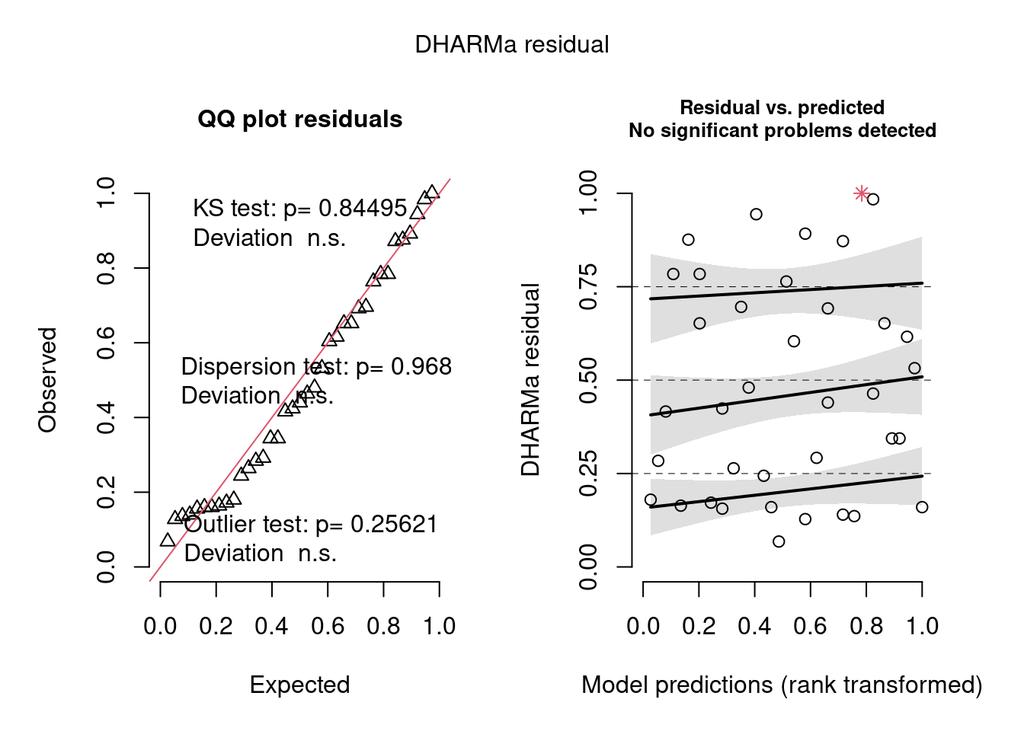

```r
# checking residuals
res_orality <- simulateResiduals(xmdl, plot = T)
```

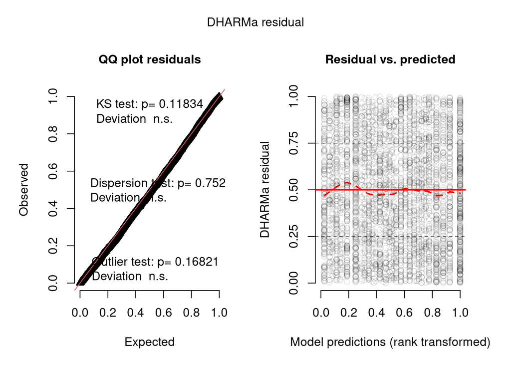

```r
res <- simulateResiduals(binary_null_mdl_int, plot = T)
```